```python
import numpy as np
import matplotlib.pyplot as plt

from tslearn.clustering import TimeSeriesKMeans
from tslearn.datasets import CachedDatasets
from tslearn.preprocessing import TimeSeriesScalerMeanVariance, \
    TimeSeriesResampler
from tslearn.utils import to_time_series_dataset
```

l'objectif de cet algo est de créer un espace de métrique sur lequel appliquer la méthode dbscan. Après un état de l'art j'ai eu l'idée d'utiliser le dynamic time warping pur notre espace de calcul.

Cet algorythme calcule une proximité entre 2 time séries en excluant les possibles décalages temporels et dilatation temporelles. Il retourne la distance minimale entre 2 time series recalibrées l'une sur l'autre et le chemin de recalibration.

On applique l'algorithme de Distance Base Clustering pour les raisons suivantes :

- Nous ne connaissons pas le nombre de clusters à détecter ce qui limite les méthodes type K_means
- Son fonctionnement sous l'idée : "dans un rayon epsilon je cherche au minimum n voisins pour initialiser un cluster et je continue de chercher les voisins dans un environnement eps de chaques poinst du cluster jusqu'à converger"
- Nos données peuvent stagner dans une position pendant un certain temps

J'ai aussi travaillé sur une méthode de dynamic based averaging pour nous permettre de conserver un élément moyen à chaques clusters. L'idée est de moyenniser tout les points associé à une dilatation du temps calculée par le chemin de recalibration.

Pour celà je pars du médoïd de chaques cluster (élément du cluster qui semble le plus proches de tout les autres) et je moyennise sur celui-ci. Ce choix s'explique par les possibles variations de taille entre les time series (pb de perte de donnée, retard au décollage, oubli d'éteindre l'emetteur à l'atérissage, pb de détection) que le médoïd semble moyenniser.

```python
seed = 8
np.random.seed(seed)
X_train, y_train, X_test, y_test = CachedDatasets().load_dataset("Trace")
X_train = X_train # Keep first 3 classes
np.random.shuffle(X_train)
# Keep only 50 time series
X_train=to_time_series_dataset(X_train)
X_train = TimeSeriesScalerMeanVariance().fit_transform(X_train[:150])
X_train = TimeSeriesResampler(sz=120).fit_transform(X_train)
sz = X_train.shape[1]
```

refréquençage de la time série pour accélérer les calculs

# Exemple d'utilisation de la méthode packagée

```python
from TSscan.tsscan import *
```

```python
ts=TSscan(0.05) # paramètres rayon epsilon de proximité et nb d'éléments pour initialiser un cluster
```

```python
ts.fit(X_train)
```

## Visualisation des clusters

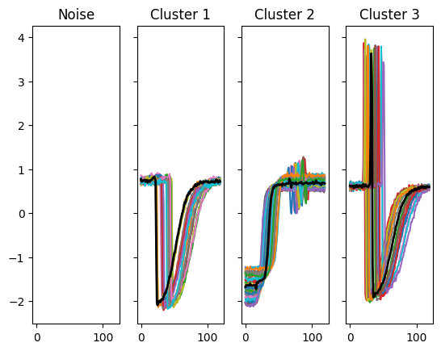

```python
ts.cluster_plot()
```

L'algo sépare en trois clusters des time series similaire et moyennise celles-ci éléments en noir

## Exemple d'éléments moyens

```python
ts.mean_cluster(0) # élément moyen du cluster 0
```

```
[array([0.77174323]),
 array([0.71703399]),
 array([0.73081107]),
 array([0.74475046]),
 array([0.73191092]),
 array([0.75613973]),
 array([0.75858765]),
 array([0.71353838]),
 array([0.73832087]),
 array([0.75380236]),
 array([0.69545619]),
 array([0.73707863]),
 array([0.74288299]),
 array([0.71397431]),
 array([0.74168053]),
 array([0.74657727]),
 array([0.7670361]),
 array([0.77440142]),
 array([0.80438741]),
 array([0.79355934]),
 array([0.83137505]),
 array([0.80239924]),
 array([0.73331]),
 array([-0.75657377]),
 array([-2.02443382]),
 array([-2.09328639]),
 array([-2.044335]),
 array([-1.99790322]),
 array([-2.00138602]),
 array([-2.02495178]),
 array([-1.9728916]),
 array([-1.977591]),
 array([-1.95225497]),
 array([-1.9620188]),
 array([-1.90735649]),
 array([-1.85895467]),
 array([-1.81821717]),
 array([-1.8220151]),
 array([-1.7581997]),
 array([-1.72040791]),
```

[output cut: 65 more lines]

```
 array([0.70142815]),
 array([0.72460875]),
 array([0.71166146]),
 array([0.71255972]),
 array([0.71962346]),
 array([0.69968978]),
 array([0.69333152]),
 array([0.73063641]),
 array([0.762556]),
 array([0.7324313]),
 array([0.74049992]),
 array([0.69533855]),
 array([0.71167228]),
 array([0.74241004]),
 array([0.71885018])]
```

```python
ts.cluster_medoid(0) # médoïd du cluster 0
```

```
(array([[ 0.80253956],
        [ 0.73227476],
        [ 0.73704014],
        [ 0.74257415],
        [ 0.7390746 ],
        [ 0.75912952],
        [ 0.76191028],
        [ 0.71334163],
        [ 0.75169534],
        [ 0.75896258],
        [ 0.69106915],
        [ 0.73631387],
        [ 0.74092089],
        [ 0.72543982],
        [ 0.73930645],
        [ 0.749878  ],
        [ 0.77009204],
        [ 0.7706459 ],
        [ 0.81062088],
        [ 0.80192929],
        [ 0.82149138],
        [ 0.79276297],
        [ 0.73842047],
        [-0.64453981],
        [-2.0802769 ],
        [-2.08070373],
        [-2.07402689],
        [-2.00382204],
        [-2.00527089],
        [-2.03747982],
        [-1.9786452 ],
        [-1.98228375],
        [-1.94942742],
        [-1.96635902],
        [-1.9138325 ],
        [-1.8508256 ],
        [-1.81387191],
        [-1.84129063],
        [-1.74085354],
        [-1.72919117],
```

[output cut: 66 more lines]

```
        [ 0.75963683],
        [ 0.70804941],
        [ 0.70959937],
        [ 0.74712595],
        [ 0.69226948],
        [ 0.68824216],
        [ 0.73666046],
        [ 0.76636005],
        [ 0.72867966],
        [ 0.75721065],
        [ 0.68236855],
        [ 0.71319952],
        [ 0.75775197],
        [ 0.72559978]]),
 89)
```

## Catégorisation des time séries

```python
ts.labels_
```

```
array([0, 0, 1, 1, 2, 1, 1, 0, 0, 2, 1, 1, 0, 2, 1, 1, 0, 2, 0, 2, 2, 2,
       1, 0, 0, 2, 1, 1, 0, 2, 1, 1, 0, 2, 0, 2, 1, 0, 2, 2, 2, 2, 2, 1,
       0, 0, 0, 2, 2, 1, 0, 1, 1, 0, 1, 1, 0, 2, 2, 0, 2, 0, 0, 1, 0, 0,
       2, 0, 0], dtype=int64)
```

### La matrice de distance calculée dans l'espace DTW

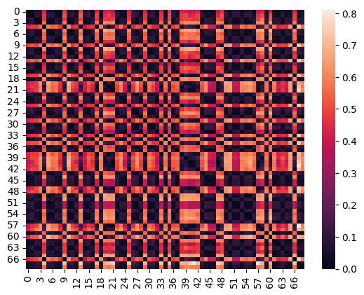

```python
sns.heatmap(pd.DataFrame(ts.divergence_matrix))
```

En résumé le package créé est applicable sur données de dimension supérieure, implémenté afin de ressembler à sklearn.clustering.DBSCAN. La limite de cet algorithme sera surement la calibration du epsilon